# US College majors

Anna Reynolds

2018-11-18

## Overview

This #TidyTuesday data set contains the data behind the story [The Economic Guide To Picking A College Major](https://fivethirtyeight.com/features/the-economic-guide-to-picking-a-college-major/) by Fivethirtyeight. All data is from American Community Survey 2010-2012 Public Use Microdata Series.

## Load data

```r
library(tidyverse)
library(stringr)
library(knitr)
library(hrbrthemes)
library(gghighlight)
library(scales)
theme_set(theme_ipsum_rc())
college_majors <- read_csv("college_majors.csv") %>% mutate(Major = str_to_title(Major)) %>% mutate(Women_percent=ShareWomen*100)
kable(head(college_majors))
```

| Rank | Major_code | Major | Total | Men | Women | Major_category | ShareWomen | Sample_size | Employed | Full_time | Part_time | Full_time_year_round | Unemployed | Unemployment_rate | Median | P25th | P75th | College_jobs | Non_college_jobs | Low_wage_jobs | Women_percent |
| --- | --- | --- | --- | --- | --- | --- | --- | --- | --- | --- | --- | --- | --- | --- | --- | --- | --- | --- | --- | --- | --- |
| 1 | 2419 | Petroleum Engineering | 2339 | 2057 | 282 | Engineering | 0.1205643 | 36 | 1976 | 1849 | 270 | 1207 | 37 | 0.0183805 | 110000 | 95000 | 125000 | 1534 | 364 | 193 | 12.05643 |
| 2 | 2416 | Mining And Mineral Engineering | 756 | 679 | 77 | Engineering | 0.1018519 | 7 | 640 | 556 | 170 | 388 | 85 | 0.1172414 | 75000 | 55000 | 90000 | 350 | 257 | 50 | 10.18519 |
| 3 | 2415 | Metallurgical Engineering | 856 | 725 | 131 | Engineering | 0.1530374 | 3 | 648 | 558 | 133 | 340 | 16 | 0.0240964 | 73000 | 50000 | 105000 | 456 | 176 | 0 | 15.30374 |
| 4 | 2417 | Naval Architecture And Marine Engineering | 1258 | 1123 | 135 | Engineering | 0.1073132 | 16 | 758 | 1069 | 150 | 692 | 40 | 0.0501253 | 70000 | 43000 | 80000 | 529 | 102 | 0 | 10.73132 |
| 5 | 2405 | Chemical Engineering | 32260 | 21239 | 11021 | Engineering | 0.3416305 | 289 | 25694 | 23170 | 5180 | 16697 | 1672 | 0.0610977 | 65000 | 50000 | 75000 | 18314 | 4440 | 972 | 34.16305 |
| 6 | 2418 | Nuclear Engineering | 2573 | 2200 | 373 | Engineering | 0.1449670 | 17 | 1857 | 2038 | 264 | 1449 | 400 | 0.1772264 | 65000 | 50000 | 102000 | 1142 | 657 | 244 | 14.49670 |

## Analysis/visualization

### What is the most popular major?

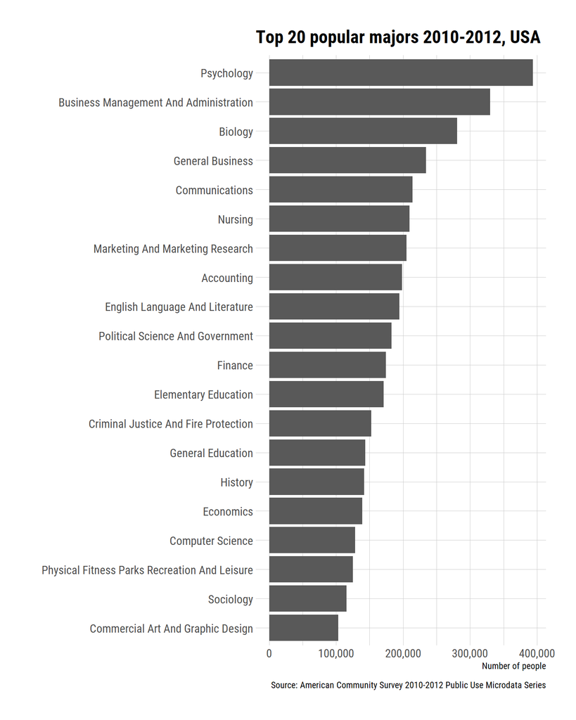

```r
top_20 <- college_majors  %>% top_n(Total,n=20)
bar1 <-
  ggplot(top_20, aes(x = reorder(Major, Total), y = Total)) + geom_bar(stat = "identity") + coord_flip() +
  scale_y_continuous(labels = comma_format()) + labs(
  x = " ",
  y = "Number of people",
  title = "Top 20 popular majors 2010-2012, USA",
  caption = "Source: American Community Survey 2010-2012 Public Use Microdata Series"
  )
  bar1
```

### Which majors have the highest and lowest proportions of women?

#### Highest proportions of women.

```r
top_20_women <- college_majors  %>% top_n(ShareWomen,n=20) %>% mutate(Women_percent=ShareWomen*100)

bar2 <-
  ggplot(top_20_women,
  aes(
  x = reorder(Major, Women_percent),
  y = Women_percent,
  fill = Major_category
  )) + geom_bar(stat = "identity") + coord_flip() + labs(
  x = " ",
  y = "Percent",
  title = "Top 20 majors with highest proportion\nof women, 2010-2012, USA",
  caption = "Source: American Community Survey 2010-2012 Public Use Microdata Series"
  ) + scale_fill_discrete(name = "Major category") +
    scale_fill_manual(values=c("#FB9A99", "#6A3D9A", "#FFFF99", "#B15928", "#CAB2D6"))
```

```
## which will replace the existing scale.
```

```r
  bar2
```

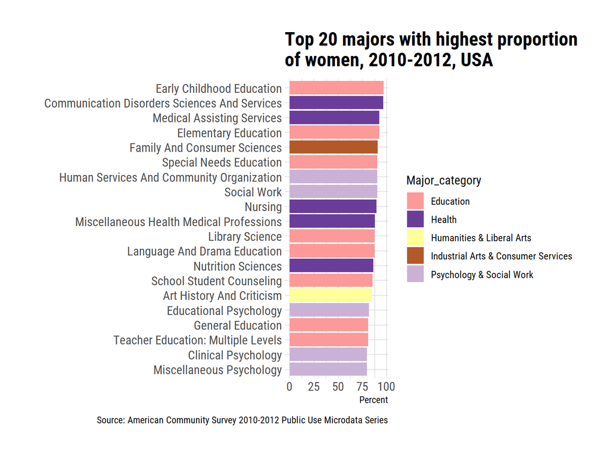

#### Lowest proportions of women.

```r
bottom_20_women <- college_majors  %>% top_n(ShareWomen,n=-20) %>% mutate(Women_percent=ShareWomen*100)
bar3 <-
  ggplot(bottom_20_women,
  aes(
  x = reorder(Major, Women_percent),
  y = Women_percent,
  fill = Major_category
  )) + geom_bar(stat = "identity") + coord_flip() + labs(
  x = " ",
  y = "Percent",
  title = "Bottom 20 majors with lowest proportion\nof women, 2010-2012, USA",
  caption = "Source: American Community Survey 2010-2012 Public Use Microdata Series"
  ) + scale_fill_discrete(name = "Major category") +
    scale_fill_brewer(palette="Paired")
```

```
## which will replace the existing scale.
```

```r
  bar3
```

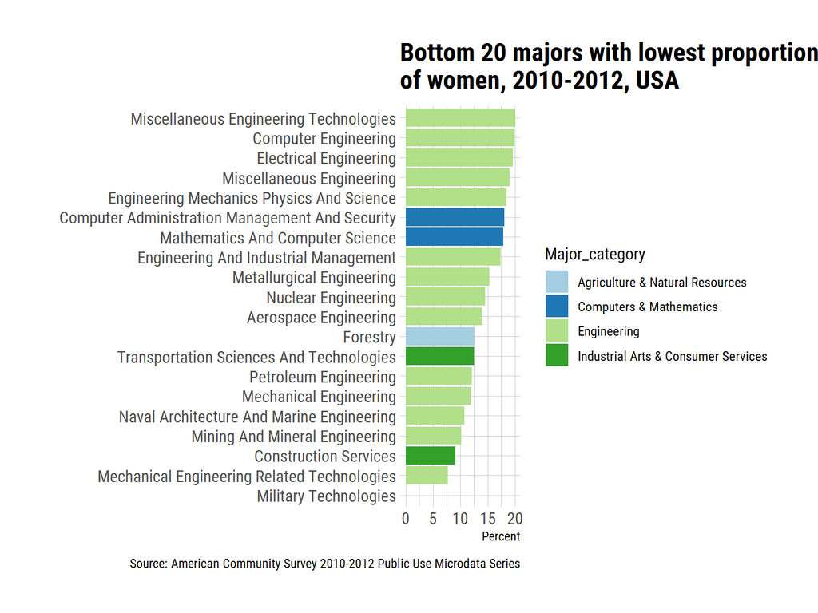

### Which majors have the highest incomes?

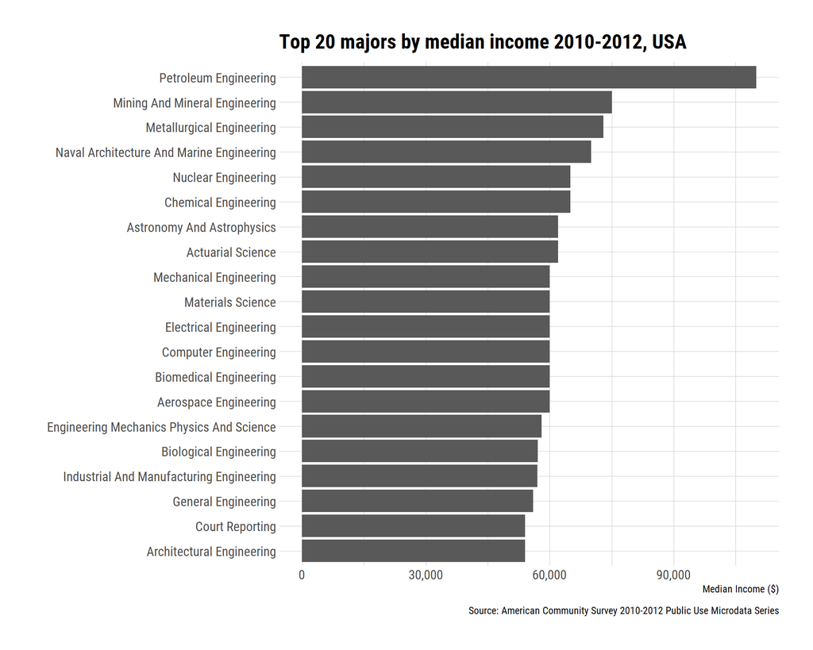

```r
top_20_inc <- college_majors  %>% top_n(Median,n=20)
bar4 <-
  ggplot(top_20_inc, aes(x = reorder(Major, Median), y = Median)) + geom_bar(stat = "identity") + coord_flip() +
  scale_y_continuous(labels = comma_format()) + labs(
  x = " ",
  y = "Median Income ($)",
  title = "Top 20 majors by median income 2010-2012, USA",
  caption = "Source: American Community Survey 2010-2012 Public Use Microdata Series"
  )
  bar4
```

### Rank by proportion of women

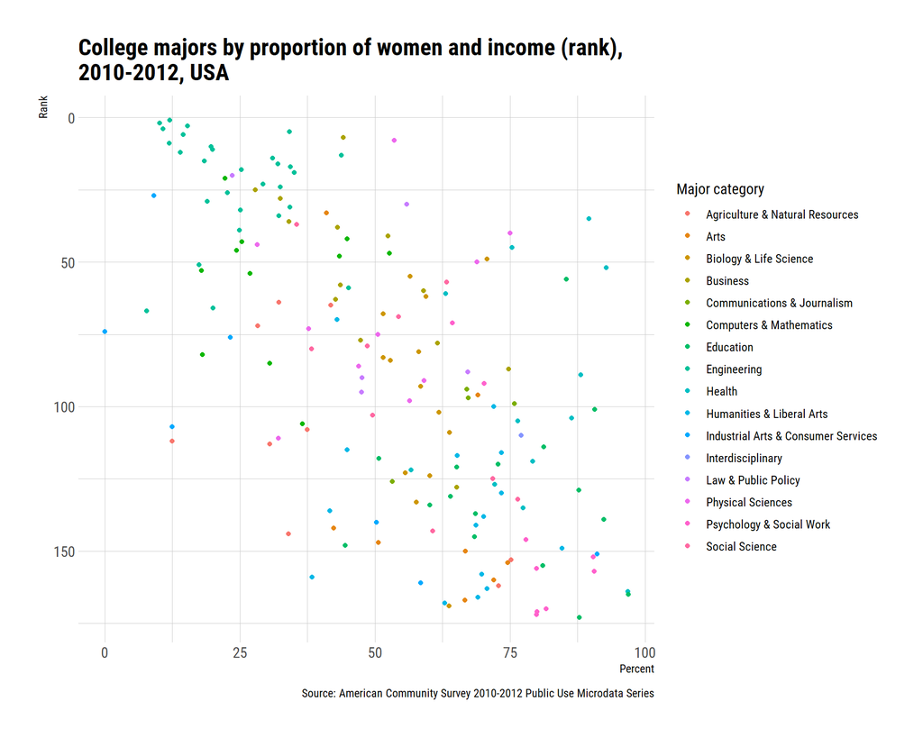

```r
scatter <-
  ggplot(college_majors,
  aes(x =  Women_percent, y = Rank, color = Major_category)) + geom_point() + labs(
  x = "Percent",
  y = "Rank",
  title = "College majors by proportion of women and income (rank), \n2010-2012, USA",
  caption = "Source: American Community Survey 2010-2012 Public Use Microdata Series"
  ) + scale_color_discrete(name = "Major category") +
  scale_y_reverse()
scatter
```

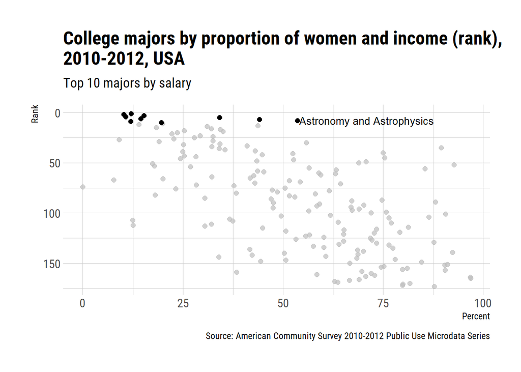

```r
scatter2 <-
  ggplot(college_majors, aes(x =  Women_percent, y = Rank)) + geom_point(size =
  2) + gghighlight(Rank < 11) + labs(
  x = "Percent",
  y = "Rank",
  title = "College majors by proportion of women and income (rank), \n2010-2012, USA",
  subtitle = "Top 10 majors by salary",
  caption = "Source: American Community Survey 2010-2012 Public Use Microdata Series"
  ) + annotate(
  "text",
  label = "Astronomy and Astrophysics",
  x = 71,
  y = 8,
  size = 3.5
  ) + scale_y_reverse()
scatter2
```

## Conclusions

- Psychology was the most popular major followed by Business Management and administration
- Education and Health majors had the highest proportion of women
- Engineering majors had the lowest proportion of women but the highest salaries
- Petroleum engineering had the highest median income
- The higher the income rank of a major, the lower the proportion of women
- Astronomy and astrophysics was an outlier, with more than 50% women and ranked number 8 for income

## Package citations

Hiroaki Yutani (2018). gghighlight: Highlight Lines and Points in ‘ggplot2’. R package version 0.1.0. https://CRAN.R-project.org/package=gghighlight

Bob Rudis (2018). hrbrthemes: Additional Themes, Theme Components and Utilities for ‘ggplot2’. R package version 0.5.0. https://CRAN.R-project.org/package=hrbrthemes

Hadley Wickham (2017). tidyverse: Easily Install and Load the ‘Tidyverse’. R package version 1.2.1. https://CRAN.R-project.org/package=tidyverse

Hadley Wickham (2018). stringr: Simple, Consistent Wrappers for Common String Operations. R package version 1.3.0. https://CRAN.R-project.org/package=stringr

Yihui Xie (2018). knitr: A General-Purpose Package for Dynamic Report Generation in R. R package version 1.20.